# R Notebook

Data: qb_revenue_breakdown qb_monthly_sales qb_competitors qb_device_data

```r
library(tidyverse)
```

```r
revenue <- CodeClanData::qb_revenue_breakdown
sales <-CodeClanData::qb_monthly_sales
competitors <- CodeClanData::qb_competitors
device <- CodeClanData::qb_device_data
```

2 MVP 2.1 Part 1 Question 1. Take the data in the dataset qb_revenue_breakdown and make a stacked bar chart showing the sources of revenue across the two years in the dataset.

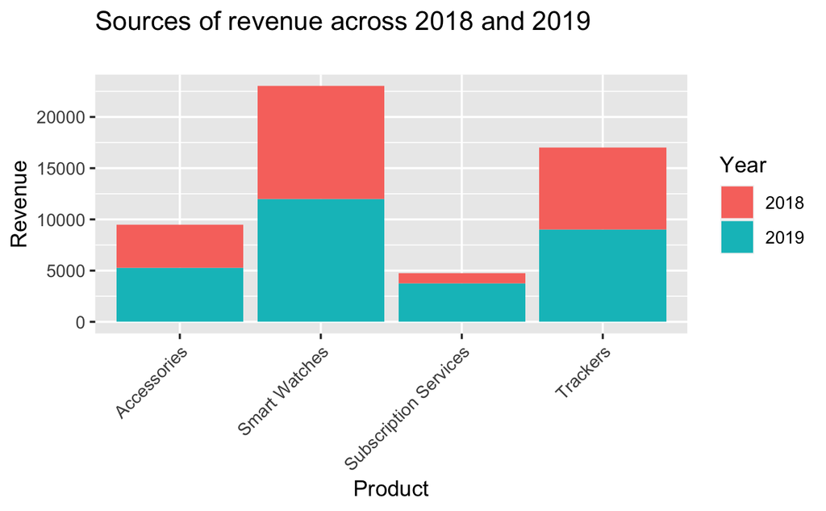

```r
revenue %>%
  ggplot(aes(x = Product, y = Revenue))+
  geom_col(aes(fill = Year)) +
  theme(axis.text.x = element_text(angle = 45, hjust = 1))+
  labs(title = "Sources of revenue across 2018 and 2019\n")
```

Question 2. Make a line chart showing monthly sales of the “flagship product” - the ‘KwikBit Unit 1’ - over the last year. This data is inside qb_monthly_sales, but you will need to use filter() or subset() (base R).

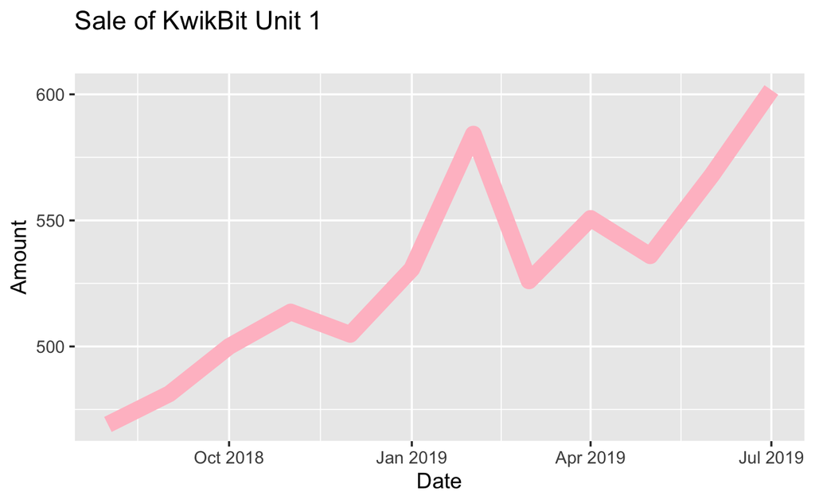

```r
sales %>%
  filter(Cashflow == "Kwikbit Unit 1 Sales") %>%
  ggplot() +
  geom_line(aes(x = Date, y = Amount, group = Cashflow),
            colour = "pink", size = 4)+
  labs(title = "Sale of KwikBit Unit 1\n")
```

Question 3. Make a line chart showing monthly revenue and costs over the last year. This data is also in qb_monthly_sales.

[figure not shown]

```r
sales %>%
  filter(Cashflow == "Total Revenue") %>%
  ggplot() +
  geom_line(aes(x = Date, y = Amount, group = Cashflow),
            colour = "lightblue", size = 4)+
  labs(title = "Cost of revenue\n")
```

Question 4. Show annual sales of personal fitness trackers over the last 5 years broken down by company as a ribbon plot (use geom_area). This data is in qb_competitors.

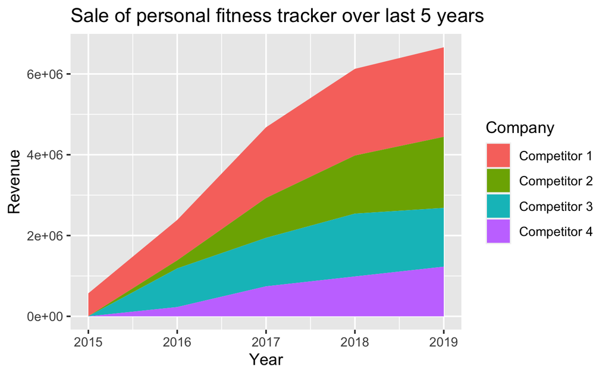

```r
competitors %>%
  ggplot(aes(x = Year,
             y = Revenue))+
  geom_area(aes(group = Company,
            fill = Company))+
  labs(title = "Sale of personal fitness tracker over last 5 years")
```

Question 5. Now show the sales from the four competitors as a line graph. Include an extra layer that shows the data points used to make the lines.

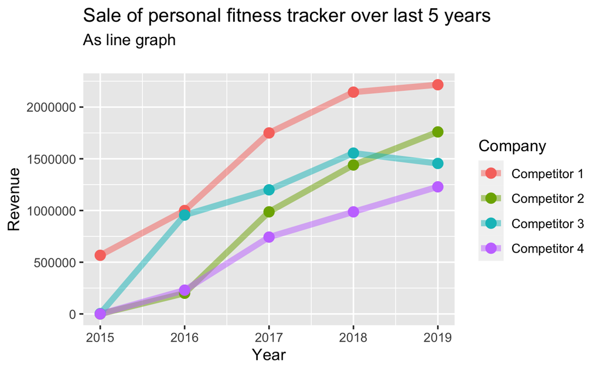

```r
competitors %>%
  ggplot(aes(x = Year,
             y = Revenue))+
  geom_line(aes(group = Company,
            colour = Company),
            size = 2,
            alpha = 0.5)+
  geom_point(aes(colour = Company),
             size = 3)+
  labs(title = "Sale of personal fitness tracker over last 5 years",
       subtitle = "As line graph\n")
```

Question 6. Now the company wants to compare the number of steps that their device counts vs. their competitors. Make a line graph of the number of steps throughout time, and use faceting to compare between companies and people. The data for this is in qb_device_data.

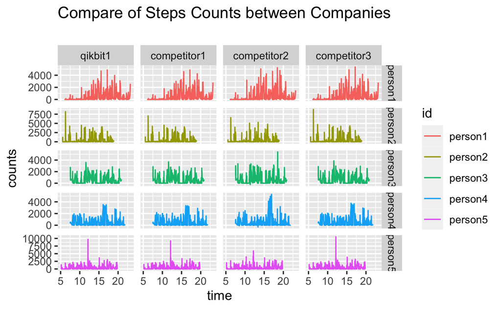

```r
device %>%
  unite(time, c(hours, mins), sep = ".") %>%
  mutate(time = as.numeric(time)) %>%
  ggplot(aes(x= time, y = counts)) +
  geom_line(aes(group = id, colour = id))+
  facet_grid(id~device,scales = "free_y")+
  labs(title = "Compare of Steps Counts between Companies\n")
```

2.2 Part 2 Question 1. Take the plots that you produced in part one and now polish them by:

Adding appropriate labels Changing the scales and coordinates when appropriate.

Applying a unified theme, which is described below: Graphs should have white backgrounds, and use colour . There should be faint grid lines. Font sizes should be ~12pt although titles should be slightly larger and axis labels can be slightly smaller. All plots should use colours from the following company colour scheme.

```r
col_scheme <- c("#E89FE9", "#50434F", "#B6A7B5", "#F9A472", "#BD7040")

my_theme <- function(base_size = 12) {
  theme( panel.background = element_rect(fill = "white", colour = "grey"),
         panel.grid.major = element_line(colour = "grey",
                                         linetype = 2,
                                        size = 0.1),
         axis.text = element_text(size = 8),
         axis.title = element_text(size = 8)
  )
}
my_theme <- list(my_theme, scale_colour_manual(values = col_scheme), scale_fill_manual(values = col_scheme))
```

```r
revenue %>%
  ggplot(aes(x = Product, y = Revenue))+
  geom_col(aes(fill = Year)) +
  theme(axis.text.x = element_text(angle = 45, hjust = 1))+
  labs(title = "Sources of revenue across 2018 and 2019\n")+
  my_theme
```

[output not shown]